# assignment6

2023-12-03

#Usman Omer 42834861 DATA 101 WITH IRENE VRBIK

# Question 1.1

# Correct answer: B

# In k-nearest neighbors regression, the prediction for a new observation is the mean of the responses of the k nearest neighbors.

# Question 1.2

# Correct answer: A

# RMSPE stands for root mean squared prediction error. It is a measure of the accuracy of a predictive model, calculated as the square root of the average squared differences between the predicted and actual values.

# Question 1.3

# Correct answer: C

# The correct formula for RMSPE is the square root of the average of the squared differences between the predicted values and the actual values, expressed as: RMSPE = sqrt(sum((predicted - actual)^2) / n).

# Question 2.1

# Loading the bike sharing dataset

```r
options(repos = c(CRAN = "https://cran.r-project.org"))
install.packages("tidyverse")
library(tidyverse)
bike_df <- read_csv("bike.csv")
```

# This command reads the bike dataset from the specified directory.

# Question 2.2

# Counting observations and variables

```r
dim(bike_df)
```

```
## [1] 17379    17
```

# The `dim` function returns the dimensions of the dataframe, showing there are 17379 observations and 17 variables in the dataset.

# Question 2.3

# Creating a subset of the dataset

```r
my_df <- bike_df |> select(atemp, hum, windspeed, cnt)
```

# This command uses the `select` function from the tidyverse package to create a new dataframe `my_df` with only the specified variables.

# Question 2.4

# Creating a histogram

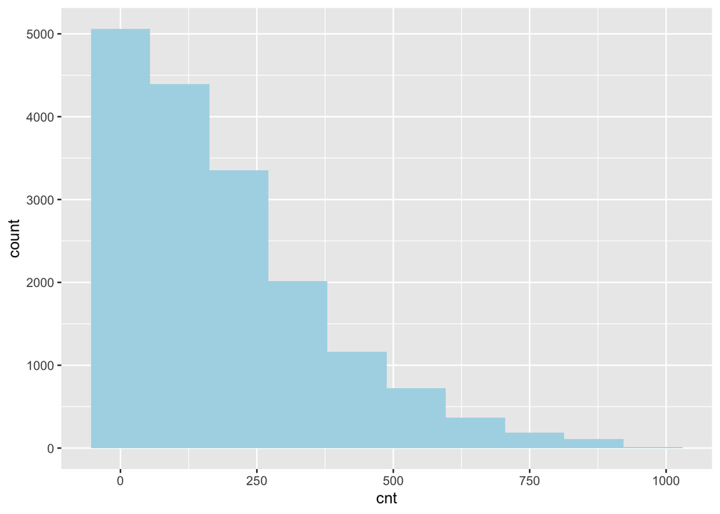

```r
my_df |>
  ggplot() +
  geom_histogram(aes(cnt), bins=10, fill="lightblue")
```

## This ggplot command creates a histogram for the ‘cnt’ variable with specified bins and fill color. The histogram helps in understanding the distribution of bike rentals.